# Tugas Praktikum 4

## Karakteristik MA(2)

### Plot Time Series

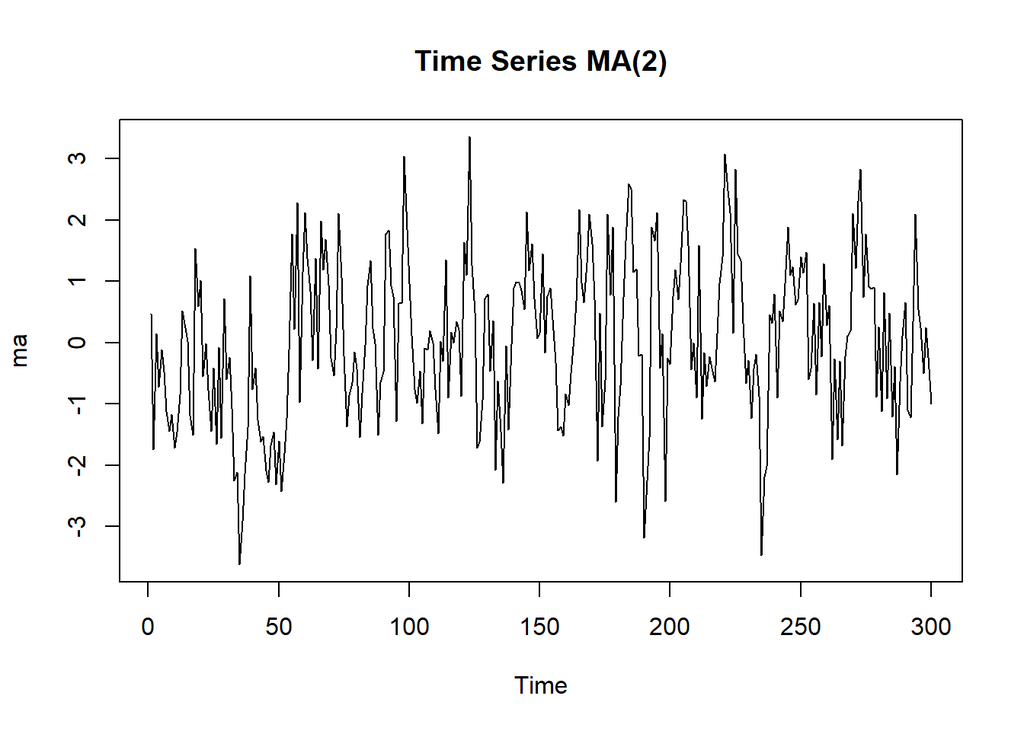

```r
ts.plot(ma, main="Time Series MA(2)")
```

Berdasarkan plot time series, terlihat bahwa data MA(2) yang dibangkitkan stasioner dalam rataan

### Plot ACF

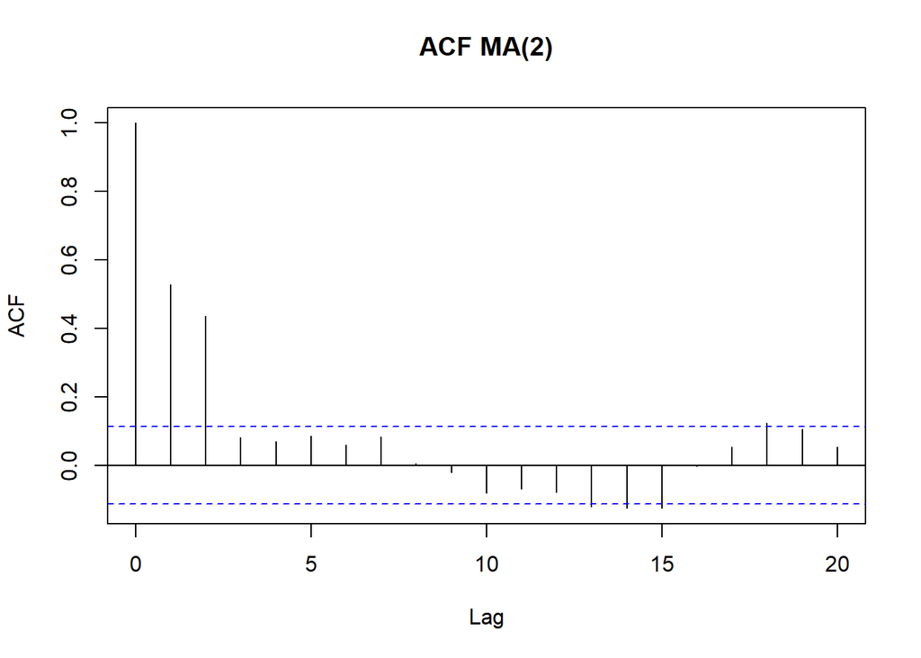

```r
acf(ma,lag.max = 20, main="ACF MA(2)")
```

Berdasarkan plot AFC tersebut, terlihat bahwa plot ACF *cuts off* di lag kedua.

### Plot PACF

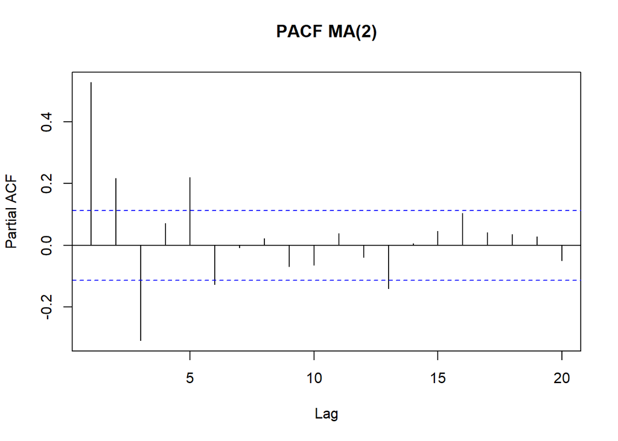

```r
pacf(ma,lag.max = 20, main="PACF MA(2)")
```

Berdasarkan plot PACF tersebut, terlihat bahwa plot PACF cenderung *tails off* dan membentuk gelombang sinus

### Plot EACF

```r
TSA::eacf(ma)
```

```
## AR/MA
##   0 1 2 3 4 5 6 7 8 9 10 11 12 13
## 0 x x o o o o o o o o o  o  x  x
## 1 x x x o o o o o o o o  o  o  o
## 2 x x x x o o o o o o o  o  o  o
## 3 x x x x o o o o o o o  o  o  o
## 4 x x x x o o o o o o o  o  o  o
## 5 x x o x x o x o o o o  o  o  o
## 6 o x o o x o o x o o o  o  o  o
## 7 x o x o x o o x o o o  o  o  o
```

Berdasarkan pola segitiga nol pada plot EACF, terlihat bahwa segitiga nol berada pada ordo AR(0) dan ordo MA(2)

## Scatter Plot dan Autokorelasi

### Korelasi antara $Y_t$ dengan $Y_{t-1}$

```r
#Yt
yt_ma <- ma[-1]
#Yt-1
yt_1_ma <- ma[-300]
```

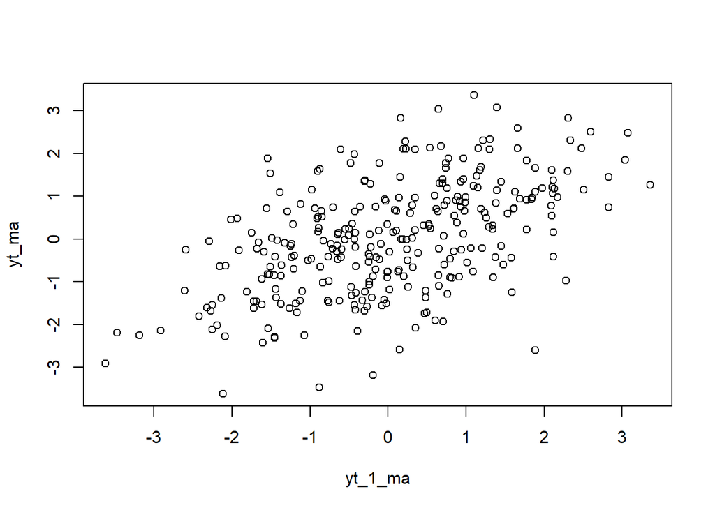

```r
plot(y=yt_ma,x=yt_1_ma)
```

```r
cor(yt_ma,yt_1_ma)
```

```
## [1] 0.5285939
```

Korelasi antara $Y_t$ dengan $Y_{t-1}$ dari hasil simulasi yaitu 0.5285939 tergolong mendekati perhitungan teoritis yaitu 0.4210526

$$\rho_1=\frac{\theta_1
+\theta_1\theta_2}{1+\theta_1^2+\theta_2^2}=\frac{0.4+(0.4)(0.6)}{1+(0.4)^2+(0.6)^2}=\frac{0.64}{1.52}=0.4210526$$

### Korelasi antara $Y_t$ dengan $Y_{t-2}$

```r
#Yt
yt_ma2 <- ma[-c(1,2)]
#Yt-2
yt_2_ma <- ma[-c(299,300)]
```

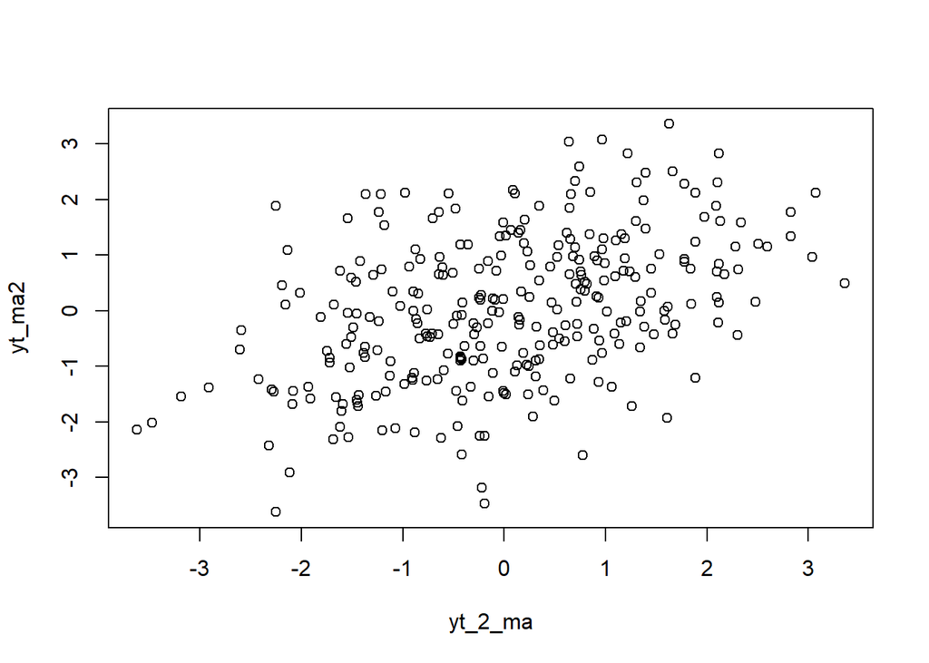

```r
plot(y=yt_ma2,x=yt_2_ma)
```

```r
cor(yt_ma2,yt_2_ma)
```

```
## [1] 0.4372298
```

$$\rho_2=\frac{\theta_2}{1+\theta_1^2+\theta_2^2}=\frac{0.6}{1+0.4^2+0.6^2}=0.3947$$

### Korelasi antara $Y_t$ dengan $Y_{t-3}$

```r
#Yt
yt_ma3 <- ma[-c(1,2,3)]
#Yt-3
yt_3_ma <- ma[-c(298, 299,300)]
```

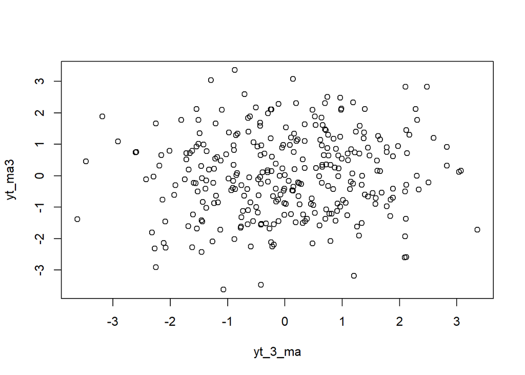

```r
plot(y=yt_ma3,x=yt_3_ma)
```

Berdasarkan scatterplot tersebut, terlihat bahwa $Y_t$ dan $Y_{t-3}$ sudah menunjukkan pola yang tidak beraturan atau bisa disebut tidak berpola.

```r
cor(yt_ma3,yt_3_ma)
```

```
## [1] 0.08239345
```

Korelasi antara $Y_t$ dengan $Y_{t-3}$ dari hasil simulasi mendekati nilai teoritis yang menyatakan bahwa $\rho_k=0$ untuk k>q.

# 2.Proses AR(2)

Proses AR dapat dituliskan sebagai berikut:

$$y_{t} = c + e_t + \phi_{1}Y_{t-1} + \phi_{2}Y_{t-2} + \dots +
\phi_{q}Y_{t-q} = c+{e_t+\sum_{i=1}^p \phi_iY_{t-i}}$$
Proses AR(2) dengan $\phi_1 = 0.5$ dan $\phi = 0.2$. Rumus:

$$Y_t = e_t + 0.5Y_{t-1} + 0.2Y_{t-2}$$

## Pembangkitan Manual Proses AR(2)

Akan dicoba membangkitkan proses AR(2) dengan $\phi_1 = 0.5$ dan $\phi_2 = 0.2$ sebanyak 300 observasi dan $c=0$. Karena diperlukan dua nilai awal untuk $Y_{t-1}$ dan $Y_{t-2}$, masukkan dua nilai pertama white noise sebagai nilai awal tersebut.

```r
set.seed(1234)
n<-length(wn)
ar <- rep(0,n)
ar[1] <- wn[1]
ar[2] <- 0.5*ar[1] + wn[2]
ar <- c(1:n)
for (i in 3:n) {ar[i]<-wn[i]+0.5*ar[i-1] + 0.2*ar[i-2]}
ar
```

```
##   [1]  1.000000000  2.000000000  2.284441177 -0.803477114  0.484274367
##   [6]  0.587497653 -0.184136260 -0.521200455 -0.861879479 -1.425217660
##  [11] -1.362177425 -1.964518689 -2.030948724 -1.343919283 -0.118655327
##  [16] -0.438397015 -0.753939079 -1.375844359 -1.675881675  1.302725469
##  [21]  0.450274620 -0.005003493 -0.352994695  0.282091395 -0.623273488
##  [26] -1.703423376 -0.401610665 -1.565145730 -0.878033298 -1.687994396
##  [31]  0.082693688 -0.771845114 -1.078823857 -1.195039012 -2.442377746
##  [36] -2.627815938 -3.982423167 -3.857767963 -3.019662474 -2.747282370
##  [41] -0.528077414 -1.882137905 -1.902049069 -1.608075117 -2.178787449
##  [46] -2.379523066 -2.732837215 -3.094309106 -2.617550115 -2.424486836
##  [51] -3.541784698 -2.837865641 -3.236179384 -3.200624830 -2.409857815
##  [56] -1.281998055  0.524846882 -0.767329594  1.327214208 -0.647667362
##  [61]  0.598197625  2.718556411  1.444157341  0.596156373  0.579304899
##  [66]  2.185968172  0.070237329  1.840139478  2.263681996  1.836341691
##  [71]  1.377800083  0.600699641  0.209385904  0.873119448  2.548707766
```

[output cut: 45 more lines]

## Pembangkitan Proses AR(2) dengan `arima.sim()`

```r
ar <- arima.sim(list(order=c(2,0,0), ar=c(0.5,0.2)), n=n)
ar
```

```
## Time Series:
## Start = 1
## End = 300
## Frequency = 1
##   [1] -1.7066325607 -0.4040571790 -1.5670108246 -0.8794551485 -1.6890783403
##   [6]  0.0818673463 -0.7724750738 -1.0793041051 -1.1954051279 -2.4426568541
##  [11] -2.6280287147 -3.9825853771 -3.8578916236 -3.0197567460 -2.7473542381
##  [16] -0.5281322030 -1.8821796728 -1.9020809107 -1.6080993919 -2.1788059544
##  [21] -2.3795371734 -2.7328479702 -3.0943173054 -2.6175563658 -2.4244916012
##  [26] -3.5417883306 -2.8378684102 -3.2361814957 -3.2006264394 -2.4098590424
##  [31] -1.2819989901  0.5248461693 -0.7673301373  1.3272137941 -0.6476676781
##  [36]  0.5981973841  2.7185562271  1.4441572006  0.5961562661  0.5793048174
##  [41]  2.1859681101  0.0702372818  1.8401394423  2.2636819683  1.8363416698
##  [46]  1.3778000670  0.6006996293  0.2093858952  0.8731194410  2.5487077608
##  [51]  1.2955793561 -0.2331697165 -0.5810507641 -0.0788975632 -0.4727180494
```

[output cut: 49 more lines]

## Karakteristik AR(2)

### Plot Time Series

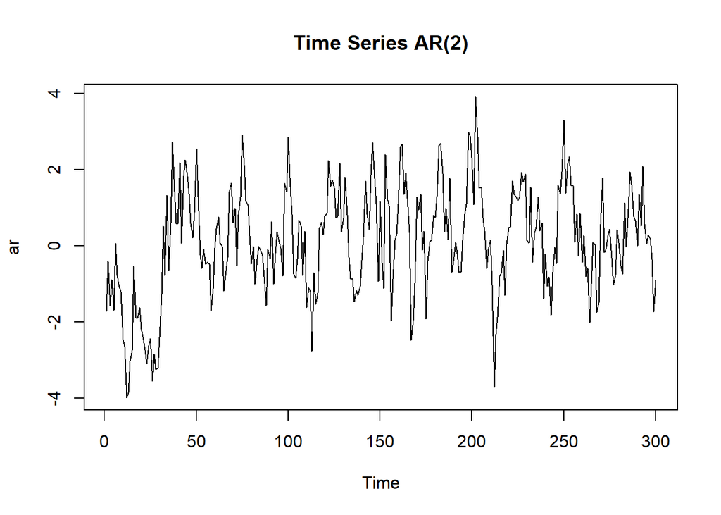

```r
ts.plot(ar, main="Time Series AR(2)")
```

Berdasarkan plot time series tersebut terlihat bahwa data cenderung stasioner pada rataan

### Plot ACF

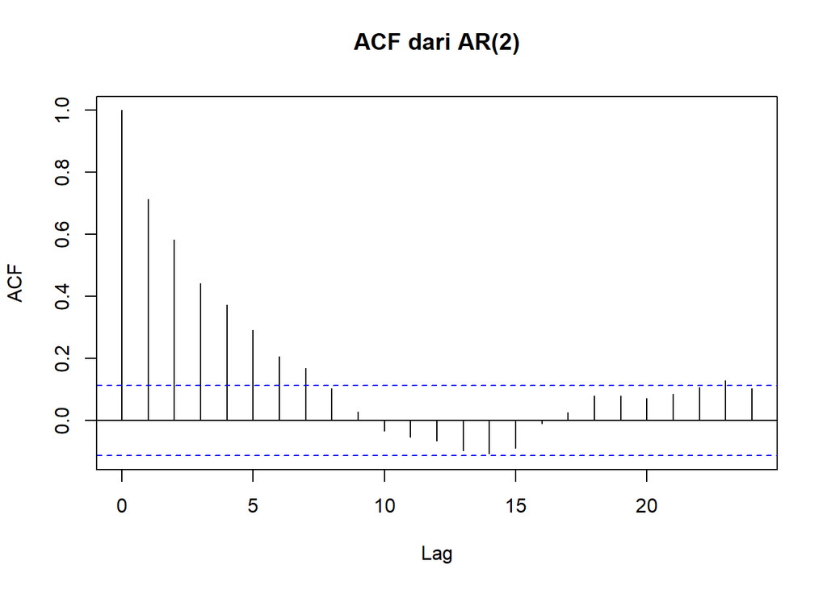

```r
acf(ar,  main="ACF dari AR(2)")
```

Berdasarkan plot ACF tersebut terlihat bahwa plot ACF cenderung *tails off* dan cenderung membentuk pola grafik sinus

### Plot PACF

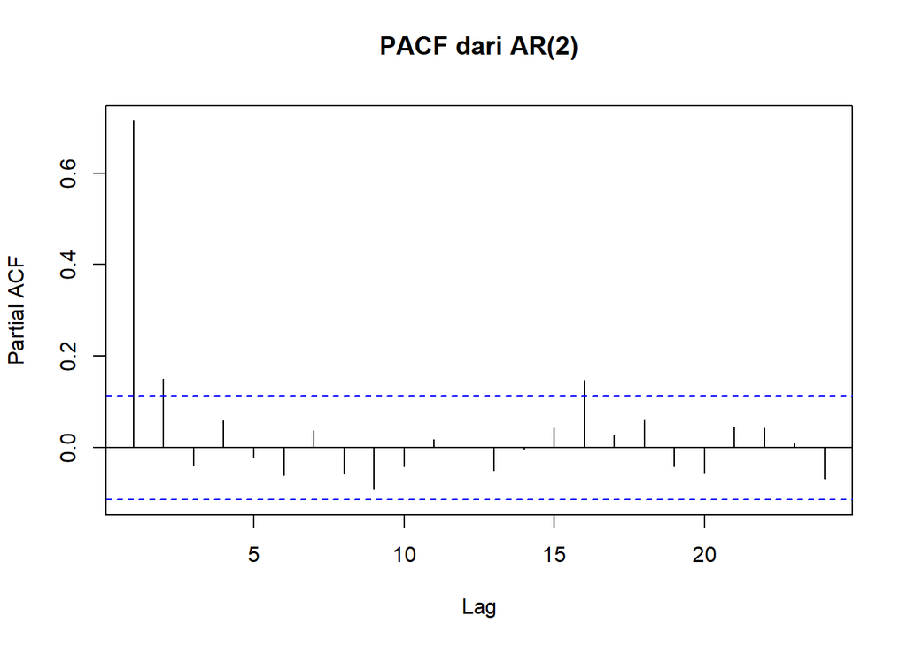

```r
pacf(ar,  main="PACF dari AR(2)")
```

Berdasarkan plot PACF tersebut, terlihat bahwa plot PACF *cuts off* pada lag kedua.

### Plot EACF

```r
TSA::eacf(ar)
```

```
## AR/MA
##   0 1 2 3 4 5 6 7 8 9 10 11 12 13
## 0 x x x x x x x o o o o  o  o  o
## 1 x o o o o o o o o o o  o  o  o
## 2 x o o o o o o o o o o  o  o  o
## 3 x x o o o o o o o o o  o  o  o
## 4 x x o o o o o o o o o  o  o  o
## 5 x x x o o o o o o o o  o  o  o
## 6 x x x o o o o o o o o  o  o  o
## 7 x x x o x x o o o o o  o  o  o
```

Berdasarkan pola segitiga nol pada plot EACF, terlihat bahwa segitiga nol berada pada ordo AR(2) dan ordo MA(0)

## Scatterplot Antar Lag

### Korelasi antara $Y_t$ dengan $Y_{t-1}$

```r
#Yt
yt_ar <- ar[-1]
yt_ar
```

```
##   [1] -0.4040571790 -1.5670108246 -0.8794551485 -1.6890783403  0.0818673463
##   [6] -0.7724750738 -1.0793041051 -1.1954051279 -2.4426568541 -2.6280287147
##  [11] -3.9825853771 -3.8578916236 -3.0197567460 -2.7473542381 -0.5281322030
##  [16] -1.8821796728 -1.9020809107 -1.6080993919 -2.1788059544 -2.3795371734
##  [21] -2.7328479702 -3.0943173054 -2.6175563658 -2.4244916012 -3.5417883306
##  [26] -2.8378684102 -3.2361814957 -3.2006264394 -2.4098590424 -1.2819989901
##  [31]  0.5248461693 -0.7673301373  1.3272137941 -0.6476676781  0.5981973841
##  [36]  2.7185562271  1.4441572006  0.5961562661  0.5793048174  2.1859681101
##  [41]  0.0702372818  1.8401394423  2.2636819683  1.8363416698  1.3778000670
##  [46]  0.6006996293  0.2093858952  0.8731194410  2.5487077608  1.2955793561
##  [51] -0.2331697165 -0.5810507641 -0.0788975632 -0.4727180494 -0.4299284950
##  [56] -0.4795019342 -1.6980385520 -1.1187068333 -0.0487288699  0.4495029101
##  [61]  0.7650030321  0.0696701226 -0.0037581027 -1.1824729064 -0.6451468925
##  [66] -0.3038720265  1.4249986155  1.6532381548  0.6160353575  0.9942156067
##  [71] -0.5142931687  0.8199001639  1.2800082016  2.9251012390  2.1330757942
```

[output cut: 45 more lines]

```r
#Yt-1
yt_1_ar <- ar[-300]
yt_1_ar
```

```
##   [1] -1.7066325607 -0.4040571790 -1.5670108246 -0.8794551485 -1.6890783403
##   [6]  0.0818673463 -0.7724750738 -1.0793041051 -1.1954051279 -2.4426568541
##  [11] -2.6280287147 -3.9825853771 -3.8578916236 -3.0197567460 -2.7473542381
##  [16] -0.5281322030 -1.8821796728 -1.9020809107 -1.6080993919 -2.1788059544
##  [21] -2.3795371734 -2.7328479702 -3.0943173054 -2.6175563658 -2.4244916012
##  [26] -3.5417883306 -2.8378684102 -3.2361814957 -3.2006264394 -2.4098590424
##  [31] -1.2819989901  0.5248461693 -0.7673301373  1.3272137941 -0.6476676781
##  [36]  0.5981973841  2.7185562271  1.4441572006  0.5961562661  0.5793048174
##  [41]  2.1859681101  0.0702372818  1.8401394423  2.2636819683  1.8363416698
##  [46]  1.3778000670  0.6006996293  0.2093858952  0.8731194410  2.5487077608
##  [51]  1.2955793561 -0.2331697165 -0.5810507641 -0.0788975632 -0.4727180494
##  [56] -0.4299284950 -0.4795019342 -1.6980385520 -1.1187068333 -0.0487288699
##  [61]  0.4495029101  0.7650030321  0.0696701226 -0.0037581027 -1.1824729064
##  [66] -0.6451468925 -0.3038720265  1.4249986155  1.6532381548  0.6160353575
##  [71]  0.9942156067 -0.5142931687  0.8199001639  1.2800082016  2.9251012390
```

[output cut: 45 more lines]

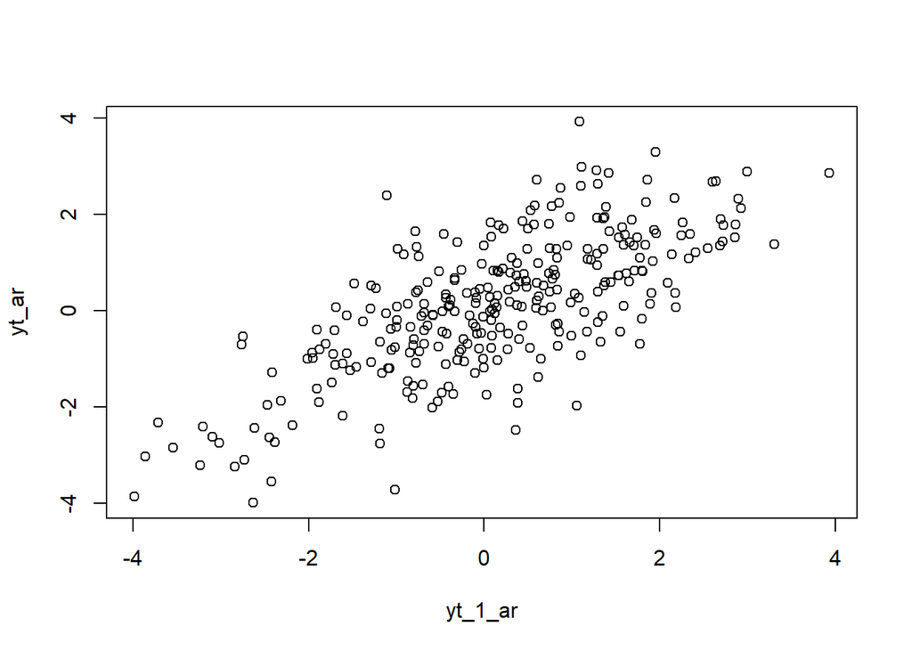

```r
plot(y=yt_ar,x=yt_1_ar)
```

Berdasarkan scatterplot tersebut, terlihat bahwa terdapat hubungan positif antara $Y_t$ dengan $Y_{t-1}$. Hal ini sesuai dengan teori yang ada

```r
cor(yt_ar,yt_1_ar)
```

```
## [1] 0.7161028
```

Korelasi antara $Y_t$ dengan $Y_{t-1}$ dari hasil simulasi mendekati perhitungan teoritis yaitu 0.625

### Korelasi antara $Y_t$ dengan $Y_{t-2}$

```r
#Yt
yt_ar2 <- ar[-c(1,2)]
yt_ar2
```

```
##   [1] -1.5670108246 -0.8794551485 -1.6890783403  0.0818673463 -0.7724750738
##   [6] -1.0793041051 -1.1954051279 -2.4426568541 -2.6280287147 -3.9825853771
##  [11] -3.8578916236 -3.0197567460 -2.7473542381 -0.5281322030 -1.8821796728
##  [16] -1.9020809107 -1.6080993919 -2.1788059544 -2.3795371734 -2.7328479702
##  [21] -3.0943173054 -2.6175563658 -2.4244916012 -3.5417883306 -2.8378684102
##  [26] -3.2361814957 -3.2006264394 -2.4098590424 -1.2819989901  0.5248461693
##  [31] -0.7673301373  1.3272137941 -0.6476676781  0.5981973841  2.7185562271
##  [36]  1.4441572006  0.5961562661  0.5793048174  2.1859681101  0.0702372818
##  [41]  1.8401394423  2.2636819683  1.8363416698  1.3778000670  0.6006996293
##  [46]  0.2093858952  0.8731194410  2.5487077608  1.2955793561 -0.2331697165
##  [51] -0.5810507641 -0.0788975632 -0.4727180494 -0.4299284950 -0.4795019342
##  [56] -1.6980385520 -1.1187068333 -0.0487288699  0.4495029101  0.7650030321
##  [61]  0.0696701226 -0.0037581027 -1.1824729064 -0.6451468925 -0.3038720265
##  [66]  1.4249986155  1.6532381548  0.6160353575  0.9942156067 -0.5142931687
##  [71]  0.8199001639  1.2800082016  2.9251012390  2.1330757942  1.1768396714
```

[output cut: 45 more lines]

```r
#Yt-2
yt_2_ar <- ar[-c(299,300)]
yt_2_ar
```

```
##   [1] -1.7066325607 -0.4040571790 -1.5670108246 -0.8794551485 -1.6890783403
##   [6]  0.0818673463 -0.7724750738 -1.0793041051 -1.1954051279 -2.4426568541
##  [11] -2.6280287147 -3.9825853771 -3.8578916236 -3.0197567460 -2.7473542381
##  [16] -0.5281322030 -1.8821796728 -1.9020809107 -1.6080993919 -2.1788059544
##  [21] -2.3795371734 -2.7328479702 -3.0943173054 -2.6175563658 -2.4244916012
##  [26] -3.5417883306 -2.8378684102 -3.2361814957 -3.2006264394 -2.4098590424
##  [31] -1.2819989901  0.5248461693 -0.7673301373  1.3272137941 -0.6476676781
##  [36]  0.5981973841  2.7185562271  1.4441572006  0.5961562661  0.5793048174
##  [41]  2.1859681101  0.0702372818  1.8401394423  2.2636819683  1.8363416698
##  [46]  1.3778000670  0.6006996293  0.2093858952  0.8731194410  2.5487077608
##  [51]  1.2955793561 -0.2331697165 -0.5810507641 -0.0788975632 -0.4727180494
##  [56] -0.4299284950 -0.4795019342 -1.6980385520 -1.1187068333 -0.0487288699
##  [61]  0.4495029101  0.7650030321  0.0696701226 -0.0037581027 -1.1824729064
##  [66] -0.6451468925 -0.3038720265  1.4249986155  1.6532381548  0.6160353575
##  [71]  0.9942156067 -0.5142931687  0.8199001639  1.2800082016  2.9251012390
```

[output cut: 45 more lines]

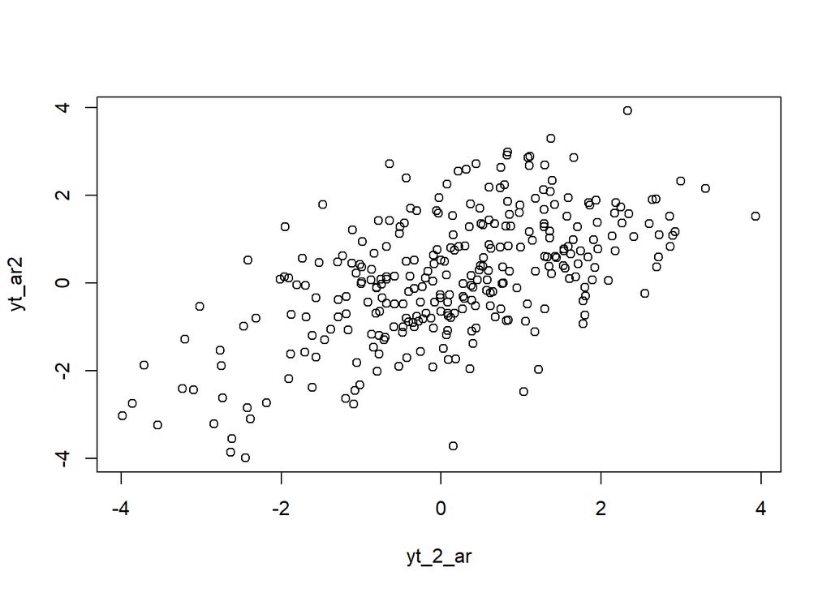

```r
plot(y=yt_ar2,x=yt_2_ar)
```

Berdasarkan scatterplot tersebut, terlihat bahwa terdapat hubungan positif antara $Y_t$ dengan $Y_{t-2}$. Hal ini sesuai dengan teori yang ada

```r
cor(yt_ar2,yt_2_ar)
```

```
## [1] 0.5866933
```

$\rho_2={\phi_1}{\rho_1}+{\phi_2}{\rho_0}={0.5}(0.625)+0.2(1)=0.5125$

### Korelasi antara $Y_t$ dengan $Y_{t-3}$

```r
#Yt
yt_ar2 <- ar[-c(1,2,3)]
yt_ar2
```

```
##   [1] -0.8794551485 -1.6890783403  0.0818673463 -0.7724750738 -1.0793041051
##   [6] -1.1954051279 -2.4426568541 -2.6280287147 -3.9825853771 -3.8578916236
##  [11] -3.0197567460 -2.7473542381 -0.5281322030 -1.8821796728 -1.9020809107
##  [16] -1.6080993919 -2.1788059544 -2.3795371734 -2.7328479702 -3.0943173054
##  [21] -2.6175563658 -2.4244916012 -3.5417883306 -2.8378684102 -3.2361814957
##  [26] -3.2006264394 -2.4098590424 -1.2819989901  0.5248461693 -0.7673301373
##  [31]  1.3272137941 -0.6476676781  0.5981973841  2.7185562271  1.4441572006
##  [36]  0.5961562661  0.5793048174  2.1859681101  0.0702372818  1.8401394423
##  [41]  2.2636819683  1.8363416698  1.3778000670  0.6006996293  0.2093858952
##  [46]  0.8731194410  2.5487077608  1.2955793561 -0.2331697165 -0.5810507641
##  [51] -0.0788975632 -0.4727180494 -0.4299284950 -0.4795019342 -1.6980385520
##  [56] -1.1187068333 -0.0487288699  0.4495029101  0.7650030321  0.0696701226
##  [61] -0.0037581027 -1.1824729064 -0.6451468925 -0.3038720265  1.4249986155
##  [66]  1.6532381548  0.6160353575  0.9942156067 -0.5142931687  0.8199001639
##  [71]  1.2800082016  2.9251012390  2.1330757942  1.1768396714  1.0810284882
```

[output cut: 45 more lines]

```r
#Yt-2
yt_3_ar <- ar[-c(298,299,300)]
yt_3_ar
```

```
##   [1] -1.7066325607 -0.4040571790 -1.5670108246 -0.8794551485 -1.6890783403
##   [6]  0.0818673463 -0.7724750738 -1.0793041051 -1.1954051279 -2.4426568541
##  [11] -2.6280287147 -3.9825853771 -3.8578916236 -3.0197567460 -2.7473542381
##  [16] -0.5281322030 -1.8821796728 -1.9020809107 -1.6080993919 -2.1788059544
##  [21] -2.3795371734 -2.7328479702 -3.0943173054 -2.6175563658 -2.4244916012
##  [26] -3.5417883306 -2.8378684102 -3.2361814957 -3.2006264394 -2.4098590424
##  [31] -1.2819989901  0.5248461693 -0.7673301373  1.3272137941 -0.6476676781
##  [36]  0.5981973841  2.7185562271  1.4441572006  0.5961562661  0.5793048174
##  [41]  2.1859681101  0.0702372818  1.8401394423  2.2636819683  1.8363416698
##  [46]  1.3778000670  0.6006996293  0.2093858952  0.8731194410  2.5487077608
##  [51]  1.2955793561 -0.2331697165 -0.5810507641 -0.0788975632 -0.4727180494
##  [56] -0.4299284950 -0.4795019342 -1.6980385520 -1.1187068333 -0.0487288699
##  [61]  0.4495029101  0.7650030321  0.0696701226 -0.0037581027 -1.1824729064
##  [66] -0.6451468925 -0.3038720265  1.4249986155  1.6532381548  0.6160353575
##  [71]  0.9942156067 -0.5142931687  0.8199001639  1.2800082016  2.9251012390
```

[output cut: 45 more lines]

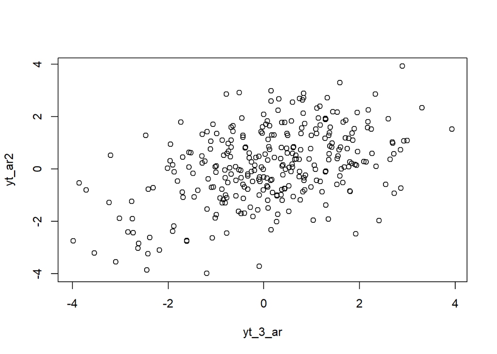

```r
plot(y=yt_ar2,x=yt_3_ar)
```

Berdasarkan scatterplot tersebut, terlihat bahwa terdapat hubungan positif antara $Y_t$ dengan $Y_{t-3}$. Hal ini sesuai dengan teori yang ada

```r
cor(yt_ar2,yt_3_ar)
```

```
## [1] 0.4467691
```

$$\rho_3={\phi_1}{\rho_2}+{\phi_2}{\rho_1}={0.5}(0.5125)+0.2(0.625)=0.38125$$

# 3. PROSES ARMA(2,2)

Proses ARMA(2,2) dapat dituliskan sebagai berikut:

$$Y_{t} = c + \sum_{i=1}^p \phi_{i}y_{t-i} + \sum_{j=1}^q e_{t-j}+ e_{t}$$
Proses ARMA(2) dengan $\phi_1 = 0.5$ dan $\phi_2 = 0.2$ dan $\theta_1 = 0.4$ dan $\theta_2 = 0.6$. Rumus:

## Pembangkitan Manual Proses ARMA(2,2)

Akan dicoba membangkitkan proses ARMA(2,2) dengan $\phi_1 = 0.5$ dan $\phi_2 = 0.2$ dan $\theta_1 = 0.4$ dan $\theta_2 = 0.6$ sebanyak 300 observasi dan $c=0$.

```r
set.seed(1234)
n <- 300
wn <- rnorm(n)

# Parameter AR dan MA
phi1 <- 0.5
phi2 <- 0.2
theta1 <- 0.4
theta2 <- 0.6

arma <- rep(0, n)
for (i in 3:300){arma[i] = phi1*arma[i-1] + phi2*arma[i-2] +
                 wn[i] + theta1*wn[i-1] + theta2*wn[i-2]}
arma
```

```
##   [1]  0.00000000  0.00000000  0.47117342 -1.50987697 -0.51919349 -1.29128499
##   [7] -0.86432398 -1.16331330 -1.88247016 -2.61769548 -2.85722080 -3.67543572
##  [13] -3.87108611 -3.51570481 -2.01254438 -1.39722573 -1.08054901 -2.00149017
##  [19] -2.72511044 -0.22860399 -0.06120480  0.93612730 -0.10054661  0.12591091
##  [25] -0.73136706 -1.79044069 -1.46225215 -2.75189059 -1.74814288 -2.98064692
##  [31] -1.12111691 -1.75293106 -1.33898765 -2.09046996 -3.56829323 -4.32225209
##  [37] -6.49932813 -7.02769509 -6.95242810 -6.26996407 -3.43890672 -3.74182891
##  [43] -2.97181976 -3.49823015 -3.96328709 -4.21591372 -4.99194225 -5.61517562
##  [49] -5.49498965 -5.32810268 -6.08211738 -5.70927763 -6.49640104 -6.19781946
##  [55] -5.63181804 -4.16631811 -1.43386858 -1.32659085  1.33518960 -0.57718012
##  [61]  1.13545868  2.56923465  2.89049818  2.80495292  1.68426168  2.77538382
##  [67]  1.29220743  3.17981524  3.04188012  3.84589813  3.47054592  2.25362466
##  [73]  1.27634579  1.31729358  3.02358708  2.83893413  1.81428668  0.10302896
##  [79] -0.45121970 -0.85290753 -0.66635425 -0.93510416 -2.14779642 -2.08562341
##  [85] -1.51503473 -0.24121274  0.91556687  0.64537308  0.48311177 -1.14217407
```

[output cut: 35 more lines]

## Pembangkitan Proses ARMA(2,2) dengan `arima.sim()`

```r
set.seed(1234)
arma <- arima.sim(list(order=c(2,0,2), ar=c(0.5,0.2), ma=c(0.4,0.6)), n=n)
arma
```

```
## Time Series:
## Start = 1
## End = 300
## Frequency = 1
##   [1] -2.75189059 -1.74814288 -2.98064692 -1.12111691 -1.75293106 -1.33898765
##   [7] -2.09046996 -3.56829323 -4.32225209 -6.49932813 -7.02769509 -6.95242810
##  [13] -6.26996407 -3.43890672 -3.74182891 -2.97181976 -3.49823015 -3.96328709
##  [19] -4.21591372 -4.99194225 -5.61517562 -5.49498965 -5.32810268 -6.08211738
##  [25] -5.70927763 -6.49640104 -6.19781946 -5.63181804 -4.16631811 -1.43386858
##  [31] -1.32659085  1.33518960 -0.57718012  1.13545868  2.56923465  2.89049818
##  [37]  2.80495292  1.68426168  2.77538382  1.29220743  3.17981524  3.04188012
##  [43]  3.84589813  3.47054592  2.25362466  1.27634579  1.31729358  3.02358708
##  [49]  2.83893413  1.81428668  0.10302896 -0.45121970 -0.85290753 -0.66635425
##  [55] -0.93510416 -2.14779642 -2.08562341 -1.51503473 -0.24121274  0.91556687
##  [61]  0.64537308  0.48311177 -1.14217407 -1.12039092 -1.27141453  0.91636167
```

[output cut: 39 more lines]

## Karakteristik ARMA(2,2)

### Plot Time Series

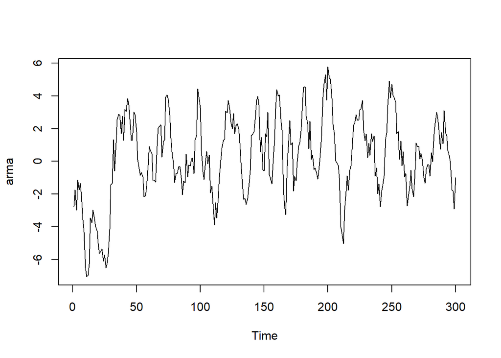

```r
ts.plot(arma)
```

Berdasarkan plot time series tersebut, terlihat bahwa model ARMA(2,2) cenderung stasioner dalam rataan

### Plot ACF

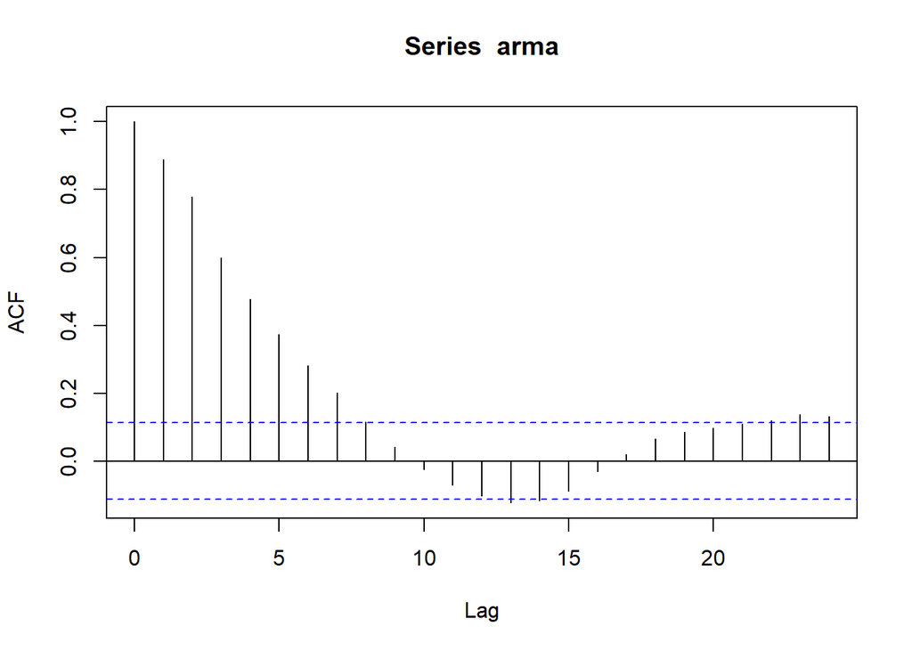

```r
acf(arma)
```

Berdasarkan plot ACF tersebut, terlihat bahwa model ARMA(2,2) hasil simulasi memiliki plot ACF yang *tails off*

### Plot PACF

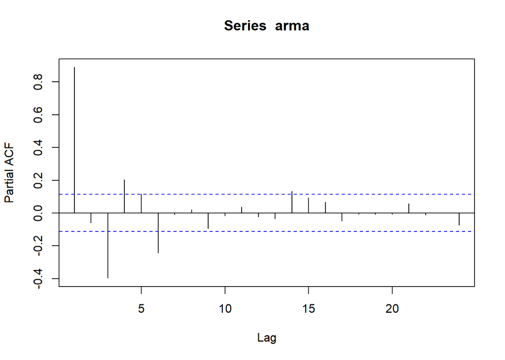

```r
pacf(arma)
```

Berdasarkan plot PACF tersebut, terlihat bahwa model ARMA(2,2) hasil simulasi memiliki plot PACF yang *tails off*

### Plot EACF

```r
TSA::eacf(arma)
```

```
## AR/MA
##   0 1 2 3 4 5 6 7 8 9 10 11 12 13
## 0 x x x x x x x o o o o  o  x  o
## 1 o x o o o o x o o o o  o  o  o
## 2 x x o o o o o o o o o  o  o  o
## 3 x x x x o o o o o o o  o  o  o
## 4 x x x x o o o o o o o  o  o  o
## 5 x x x x x x x o o o o  o  o  o
## 6 o o x o x x o o o o o  o  o  o
## 7 x o x x x x o x o o o  o  o  o
```

Berdasarkan pola segitiga nol pada plot EACF, terlihat bahwa segitiga nol berada pada ordo AR(2) dan ordo MA(2)

## Scatterplot Antar Lag

### Korelasi antara $Y_t$ dengan $Y_{t-1}$

```r
#Yt
yt_arma <- arma[-1]
yt_arma
```

```
##   [1] -1.74814288 -2.98064692 -1.12111691 -1.75293106 -1.33898765 -2.09046996
##   [7] -3.56829323 -4.32225209 -6.49932813 -7.02769509 -6.95242810 -6.26996407
##  [13] -3.43890672 -3.74182891 -2.97181976 -3.49823015 -3.96328709 -4.21591372
##  [19] -4.99194225 -5.61517562 -5.49498965 -5.32810268 -6.08211738 -5.70927763
##  [25] -6.49640104 -6.19781946 -5.63181804 -4.16631811 -1.43386858 -1.32659085
##  [31]  1.33518960 -0.57718012  1.13545868  2.56923465  2.89049818  2.80495292
##  [37]  1.68426168  2.77538382  1.29220743  3.17981524  3.04188012  3.84589813
##  [43]  3.47054592  2.25362466  1.27634579  1.31729358  3.02358708  2.83893413
##  [49]  1.81428668  0.10302896 -0.45121970 -0.85290753 -0.66635425 -0.93510416
##  [55] -2.14779642 -2.08562341 -1.51503473 -0.24121274  0.91556687  0.64537308
##  [61]  0.48311177 -1.14217407 -1.12039092 -1.27141453  0.91636167  2.04091439
##  [67]  2.13232979  2.23257264  0.25301429  1.21071226  1.29939237  3.92904462
##  [73]  4.07112121  3.78513073  2.83160983  1.41191959  0.28488816 -0.04006883
##  [79] -1.28812485 -0.74220308 -0.74424287 -0.32976863 -0.31752860 -0.98342470
##  [85] -2.04217397 -1.20184647 -1.31314616  0.45270778 -0.93468943 -0.20680752
```

[output cut: 35 more lines]

```r
#Yt-1
yt_1_arma <- arma[-300]
yt_1_arma
```

```
##   [1] -2.75189059 -1.74814288 -2.98064692 -1.12111691 -1.75293106 -1.33898765
##   [7] -2.09046996 -3.56829323 -4.32225209 -6.49932813 -7.02769509 -6.95242810
##  [13] -6.26996407 -3.43890672 -3.74182891 -2.97181976 -3.49823015 -3.96328709
##  [19] -4.21591372 -4.99194225 -5.61517562 -5.49498965 -5.32810268 -6.08211738
##  [25] -5.70927763 -6.49640104 -6.19781946 -5.63181804 -4.16631811 -1.43386858
##  [31] -1.32659085  1.33518960 -0.57718012  1.13545868  2.56923465  2.89049818
##  [37]  2.80495292  1.68426168  2.77538382  1.29220743  3.17981524  3.04188012
##  [43]  3.84589813  3.47054592  2.25362466  1.27634579  1.31729358  3.02358708
##  [49]  2.83893413  1.81428668  0.10302896 -0.45121970 -0.85290753 -0.66635425
##  [55] -0.93510416 -2.14779642 -2.08562341 -1.51503473 -0.24121274  0.91556687
##  [61]  0.64537308  0.48311177 -1.14217407 -1.12039092 -1.27141453  0.91636167
##  [67]  2.04091439  2.13232979  2.23257264  0.25301429  1.21071226  1.29939237
##  [73]  3.92904462  4.07112121  3.78513073  2.83160983  1.41191959  0.28488816
##  [79] -0.04006883 -1.28812485 -0.74220308 -0.74424287 -0.32976863 -0.31752860
##  [85] -0.98342470 -2.04217397 -1.20184647 -1.31314616  0.45270778 -0.93468943
```

[output cut: 35 more lines]

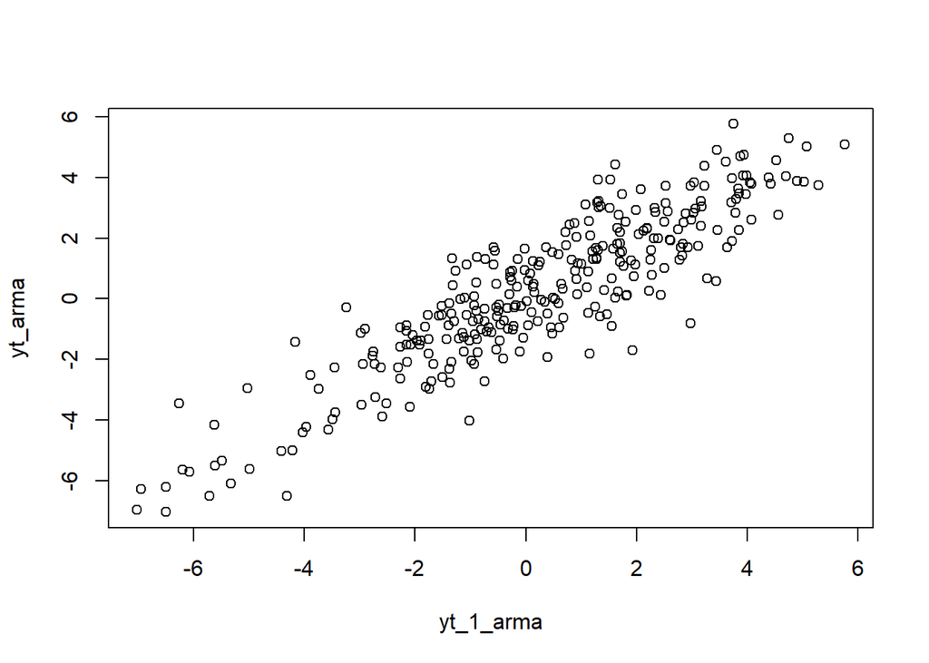

```r
plot(y=yt_arma,x=yt_1_arma)
```

Berdasarkan scatterplot tersebut, terlihat bahwa terdapat hubungan positif antara $Y_t$ dengan $Y_{t-1}$. Hal ini sesuai dengan teori yang ada

```r
cor(yt_arma,yt_1_arma)
```

```
## [1] 0.8918177
```

$$\gamma_1 = \phi_1 \gamma_0 + \phi_2 \gamma_1 + \sigma^2 (\theta_1 +
\theta_1 \theta_2 + \theta_2)= \frac{0.5(3.7083) + (0.4 + 0.4(0.6) +
0.6)}
{1 - 0.2}
= 3.3064$$

$$\rho_1 =
\frac{\gamma_1}{\gamma_0}
= 0.8918$$

### Korelasi antara $Y_t$ dengan $Y_{t-2}$

```r
#Yt
yt_arma2 <- arma[-c(1,2)]
yt_arma2
```

```
##   [1] -2.98064692 -1.12111691 -1.75293106 -1.33898765 -2.09046996 -3.56829323
##   [7] -4.32225209 -6.49932813 -7.02769509 -6.95242810 -6.26996407 -3.43890672
##  [13] -3.74182891 -2.97181976 -3.49823015 -3.96328709 -4.21591372 -4.99194225
##  [19] -5.61517562 -5.49498965 -5.32810268 -6.08211738 -5.70927763 -6.49640104
##  [25] -6.19781946 -5.63181804 -4.16631811 -1.43386858 -1.32659085  1.33518960
##  [31] -0.57718012  1.13545868  2.56923465  2.89049818  2.80495292  1.68426168
##  [37]  2.77538382  1.29220743  3.17981524  3.04188012  3.84589813  3.47054592
##  [43]  2.25362466  1.27634579  1.31729358  3.02358708  2.83893413  1.81428668
##  [49]  0.10302896 -0.45121970 -0.85290753 -0.66635425 -0.93510416 -2.14779642
##  [55] -2.08562341 -1.51503473 -0.24121274  0.91556687  0.64537308  0.48311177
##  [61] -1.14217407 -1.12039092 -1.27141453  0.91636167  2.04091439  2.13232979
##  [67]  2.23257264  0.25301429  1.21071226  1.29939237  3.92904462  4.07112121
##  [73]  3.78513073  2.83160983  1.41191959  0.28488816 -0.04006883 -1.28812485
##  [79] -0.74220308 -0.74424287 -0.32976863 -0.31752860 -0.98342470 -2.04217397
##  [85] -1.20184647 -1.31314616  0.45270778 -0.93468943 -0.20680752 -0.29613748
```

[output cut: 35 more lines]

```r
#Yt-1
yt_2_arma <- arma[-c(299,300)]
yt_2_arma
```

```
##   [1] -2.75189059 -1.74814288 -2.98064692 -1.12111691 -1.75293106 -1.33898765
##   [7] -2.09046996 -3.56829323 -4.32225209 -6.49932813 -7.02769509 -6.95242810
##  [13] -6.26996407 -3.43890672 -3.74182891 -2.97181976 -3.49823015 -3.96328709
##  [19] -4.21591372 -4.99194225 -5.61517562 -5.49498965 -5.32810268 -6.08211738
##  [25] -5.70927763 -6.49640104 -6.19781946 -5.63181804 -4.16631811 -1.43386858
##  [31] -1.32659085  1.33518960 -0.57718012  1.13545868  2.56923465  2.89049818
##  [37]  2.80495292  1.68426168  2.77538382  1.29220743  3.17981524  3.04188012
##  [43]  3.84589813  3.47054592  2.25362466  1.27634579  1.31729358  3.02358708
##  [49]  2.83893413  1.81428668  0.10302896 -0.45121970 -0.85290753 -0.66635425
##  [55] -0.93510416 -2.14779642 -2.08562341 -1.51503473 -0.24121274  0.91556687
##  [61]  0.64537308  0.48311177 -1.14217407 -1.12039092 -1.27141453  0.91636167
##  [67]  2.04091439  2.13232979  2.23257264  0.25301429  1.21071226  1.29939237
##  [73]  3.92904462  4.07112121  3.78513073  2.83160983  1.41191959  0.28488816
##  [79] -0.04006883 -1.28812485 -0.74220308 -0.74424287 -0.32976863 -0.31752860
##  [85] -0.98342470 -2.04217397 -1.20184647 -1.31314616  0.45270778 -0.93468943
```

[output cut: 35 more lines]

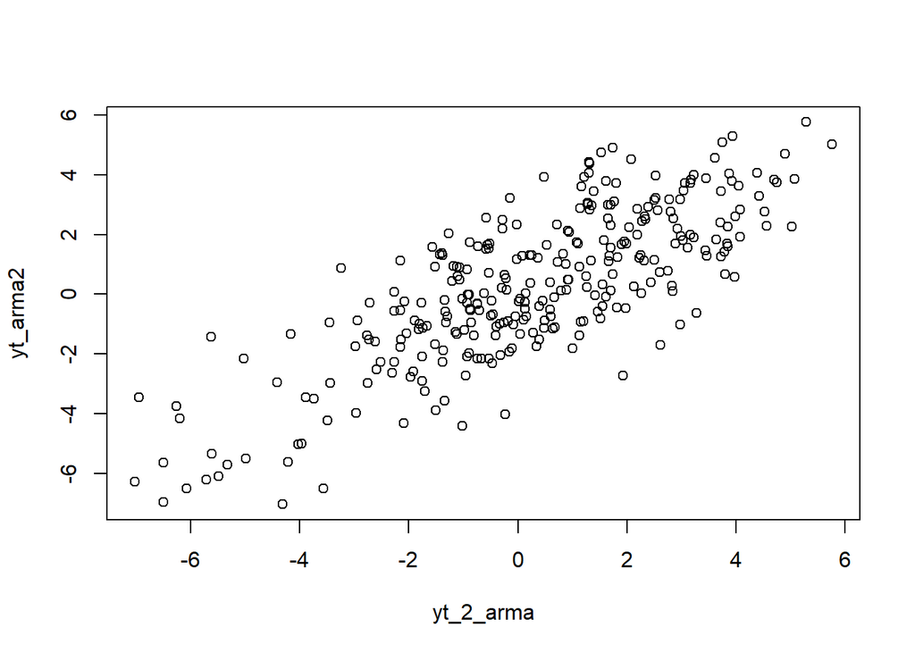

```r
plot(y=yt_arma2,x=yt_2_arma)
```

Berdasarkan scatterplot tersebut, terlihat bahwa terdapat hubungan positif antara $Y_t$ dengan $Y_{t-2}$. Hal ini sesuai dengan teori yang ada

```r
cor(yt_arma2,yt_2_arma)
```

```
## [1] 0.7836583
```

Korelasi antara $Y_t$ dengan $Y_{t-2}$ dari hasil simulasi ysitu 0.7836583 mendekati perhitungan teoritis yaitu

$$\gamma_2 = \phi_1 \gamma_1 + \phi_2 \gamma_0 +
\sigma^2 \bigl(\theta_2 + \phi_1 \theta_1\bigr)
0.5(3.3064) + 0.2(3.7083) + (0.6 + 0.5(0.4)) = 3.1949$$

$$\rho_2 = \frac{\gamma_2}{\gamma_0}=\frac{3.1949}{3.7083} = 0.8619$$

### Korelasi antara $Y_t$ dengan $Y_{t-3}$

```r
#Yt
yt_arma3 <- arma[-c(1,2,3)]
yt_arma3
```

```
##   [1] -1.12111691 -1.75293106 -1.33898765 -2.09046996 -3.56829323 -4.32225209
##   [7] -6.49932813 -7.02769509 -6.95242810 -6.26996407 -3.43890672 -3.74182891
##  [13] -2.97181976 -3.49823015 -3.96328709 -4.21591372 -4.99194225 -5.61517562
##  [19] -5.49498965 -5.32810268 -6.08211738 -5.70927763 -6.49640104 -6.19781946
##  [25] -5.63181804 -4.16631811 -1.43386858 -1.32659085  1.33518960 -0.57718012
##  [31]  1.13545868  2.56923465  2.89049818  2.80495292  1.68426168  2.77538382
##  [37]  1.29220743  3.17981524  3.04188012  3.84589813  3.47054592  2.25362466
##  [43]  1.27634579  1.31729358  3.02358708  2.83893413  1.81428668  0.10302896
##  [49] -0.45121970 -0.85290753 -0.66635425 -0.93510416 -2.14779642 -2.08562341
##  [55] -1.51503473 -0.24121274  0.91556687  0.64537308  0.48311177 -1.14217407
##  [61] -1.12039092 -1.27141453  0.91636167  2.04091439  2.13232979  2.23257264
##  [67]  0.25301429  1.21071226  1.29939237  3.92904462  4.07112121  3.78513073
##  [73]  2.83160983  1.41191959  0.28488816 -0.04006883 -1.28812485 -0.74220308
##  [79] -0.74424287 -0.32976863 -0.31752860 -0.98342470 -2.04217397 -1.20184647
##  [85] -1.31314616  0.45270778 -0.93468943 -0.20680752 -0.29613748  0.15497575
```

[output cut: 35 more lines]

```r
#Yt-1
yt_3_arma <- arma[-c(298,299,300)]
yt_3_arma
```

```
##   [1] -2.75189059 -1.74814288 -2.98064692 -1.12111691 -1.75293106 -1.33898765
##   [7] -2.09046996 -3.56829323 -4.32225209 -6.49932813 -7.02769509 -6.95242810
##  [13] -6.26996407 -3.43890672 -3.74182891 -2.97181976 -3.49823015 -3.96328709
##  [19] -4.21591372 -4.99194225 -5.61517562 -5.49498965 -5.32810268 -6.08211738
##  [25] -5.70927763 -6.49640104 -6.19781946 -5.63181804 -4.16631811 -1.43386858
##  [31] -1.32659085  1.33518960 -0.57718012  1.13545868  2.56923465  2.89049818
##  [37]  2.80495292  1.68426168  2.77538382  1.29220743  3.17981524  3.04188012
##  [43]  3.84589813  3.47054592  2.25362466  1.27634579  1.31729358  3.02358708
##  [49]  2.83893413  1.81428668  0.10302896 -0.45121970 -0.85290753 -0.66635425
##  [55] -0.93510416 -2.14779642 -2.08562341 -1.51503473 -0.24121274  0.91556687
##  [61]  0.64537308  0.48311177 -1.14217407 -1.12039092 -1.27141453  0.91636167
##  [67]  2.04091439  2.13232979  2.23257264  0.25301429  1.21071226  1.29939237
##  [73]  3.92904462  4.07112121  3.78513073  2.83160983  1.41191959  0.28488816
##  [79] -0.04006883 -1.28812485 -0.74220308 -0.74424287 -0.32976863 -0.31752860
##  [85] -0.98342470 -2.04217397 -1.20184647 -1.31314616  0.45270778 -0.93468943
```

[output cut: 35 more lines]

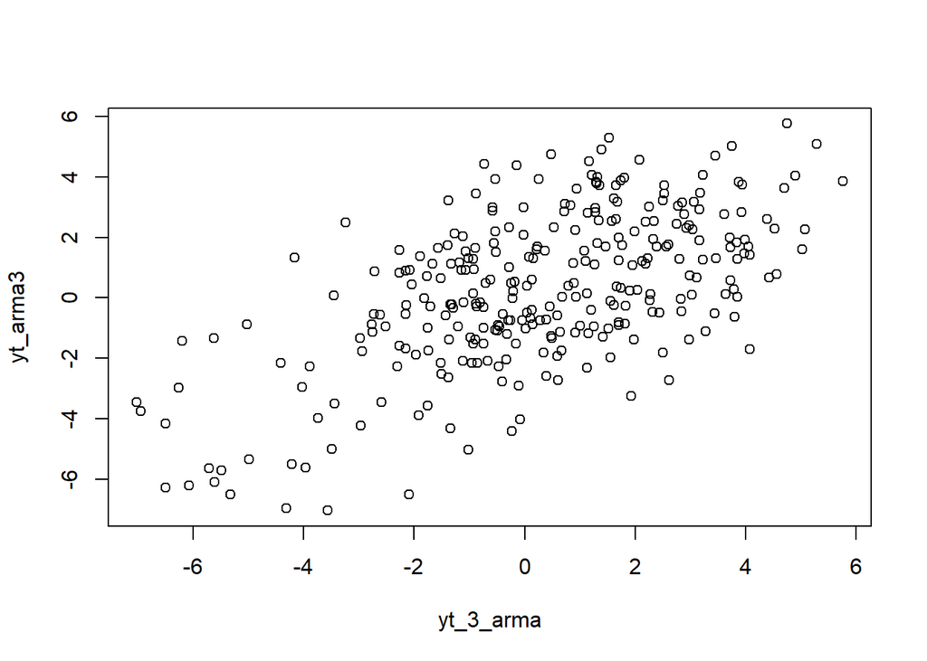

```r
plot(y=yt_arma3,x=yt_3_arma)
```

Berdasarkan scatterplot tersebut, terlihat bahwa terdapat hubungan positif antara $Y_t$ dengan $Y_{t-3}$. Hal ini sesuai dengan teori yang ada

```r
cor(yt_arma3,yt_3_arma)
```

```
## [1] 0.6044325
```

Korelasi antara $Y_t$ dengan $Y_{t-3}$ dari hasil simulasi yaitu 0.6044325 mendekati perhitungan teoritis yaitu

$$\gamma_3 = \phi_1 \gamma_2 + \phi_2 \gamma_1 =
0.5(3.1949) + 0.2(3.3064) = 2.2587$$

$$\rho_3 = \frac{\gamma_3}{\gamma_0} = \frac{2.2587}{3.7083} = 0.6094$$